# Урванов Егор

# Climate Change Earth Surface Temperature Data

# МГУ, 8 октября, 2018

## Немного про plot.ly

- Стал бесплатным
- Не нужна регистрация
- Динамические графики и картинки
- Плохое качество при экспорте картинок
- Всё-таки сыроват

## Немного про Jupyter Notebook Slides

- Возможность писать код и демонстрировать результаты сразу же при помощи RISE
- Jupyter Notebook Slides сыроват (многое нужно делать с помощью правки конфигов). Но если принаровиться, то это клёво
- Возникли проблемы со скоролом. Следует залезть в `~/.local/share/jupyter/nbextensions/rise/main.js` и найти там `scroll: false` (или `scroll: true`, тогда проблемы нет)
- Глюки
- Нельзя по-дефолту убрать код

Нужны грязные хаки

```
from IPython.display import HTML
HTML('''<script>
code_show=true;
function code_toggle() {
 if (code_show){
 $('div.input').hide();
 } else {
 $('div.input').show();
 }
 code_show = !code_show
}
$( document ).ready(code_toggle);
</script>
The raw code for this IPython notebook is by default hidden for easier reading.
To toggle on/off the raw code, click <a href="javascript:code_toggle()">here</a>.''')
```

# Описание данных

**Известные данные**

- Date: данные даны с 1750 года
- LandAverageTemperature: средняя температура на Земле (суша) в градусах Цельсия
- LandAverageTemperatureUncertainty: точность измерения (95% доверительный интервал)
- LandMaxTemperature: максимальная температура в градусах Цельсия
- LandMaxTemperatureUncertainty: точность измерения (95% доверительный интервал)
- LandMinTemperature: минимальная температура в градусах Цельсия
- LandMinTemperatureUncertainty: точность измерения (95% доверительный интервал)
- LandAndOceanAverageTemperature: средняя температура океана и суши в градусах Цельсия
- LandAndOceanAverageTemperatureUncertainty: точность измерения (95% доверительный интервал)

Такие данные есть для стран, крупных городов и столиц, для регионов, в среднем, по Земле (на суше и в океане)

Данные есть не всегда, не для всех городов, стран, регионов и дат

# Эксперименты

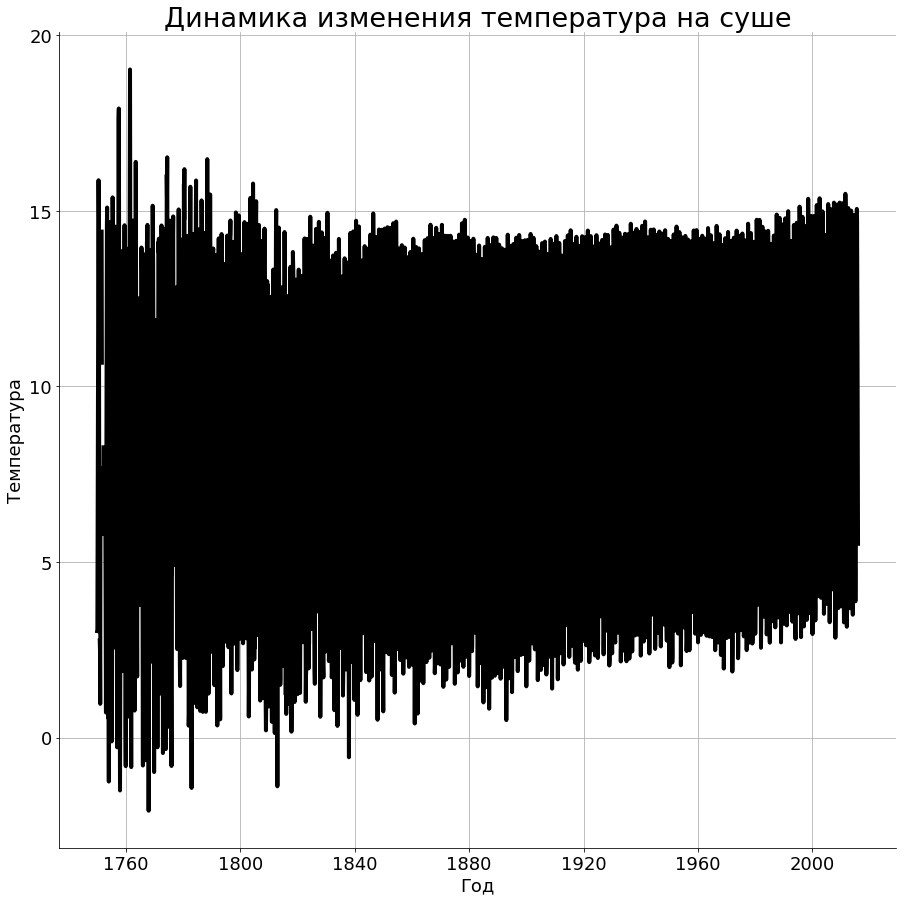

```python
plt.figure(figsize=(15, 15))
ax = plt.subplot(111)
fontsize = 18
roll_step = 1
x = temperature['dt']
y = temperature['LandAverageTemperature'].rolling(roll_step, min_periods=1, center=True).mean()
plt.plot(x, y, linewidth=4, color='k')
plt.title('Динамика изменения температура на суше', fontsize=fontsize*1.5)
plt.xticks(fontsize=fontsize)
plt.yticks(fontsize=fontsize)
plt.grid(True)
ax.spines['right'].set_visible(False)
ax.spines['top'].set_visible(False)
plt.xlabel('Год', fontsize=fontsize)
plt.ylabel('Температура', fontsize=fontsize);
```

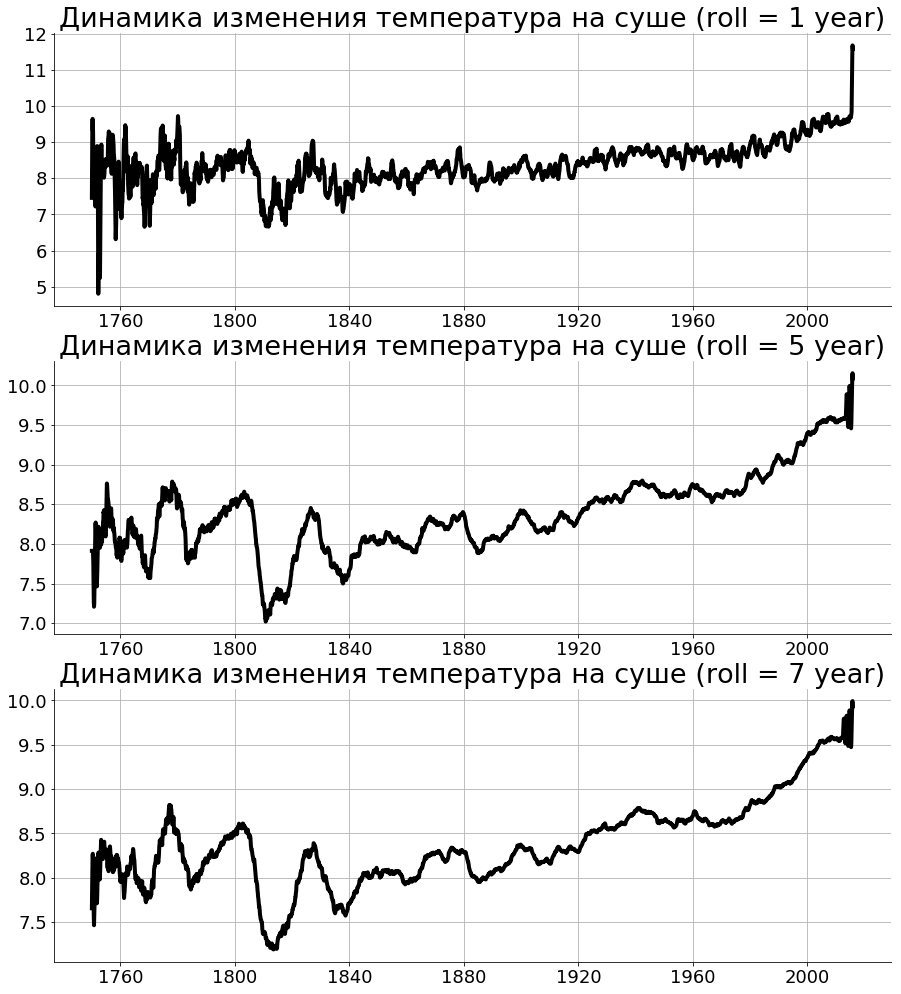

```python
plt.figure(figsize=(15, 12))
plt.subplots_adjust(top=1.2)
ax = plt.subplot(311)
plot_land_avg_temperature(ax, temperature, 1, is_reg_visible=False)
ax = plt.subplot(312)
plot_land_avg_temperature(ax, temperature, 5, is_reg_visible=False)
ax = plt.subplot(313)
plot_land_avg_temperature(ax, temperature, 7, is_reg_visible=False);
```

На этих графиках есть несколько особенностей.

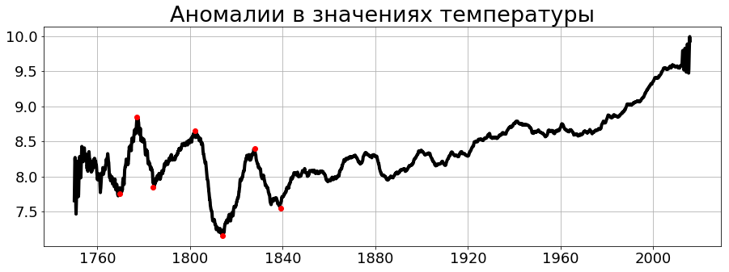

```python
plt.figure(figsize=(15, 5))
plot_land_avg_temperature(ax, temperature, 7, is_reg_visible=False)
plt.title('Аномалии в значениях температуры', fontsize=18 * 1.5)
plt.plot(datetime(year=1769, month=7, day=1), 7.75, 'ro', markersize=6)
plt.plot(datetime(year=1777, month=1, day=1), 8.85, 'ro', markersize=6)
plt.plot(datetime(year=1784, month=1, day=1), 7.85, 'ro', markersize=6)
plt.plot(datetime(year=1802, month=1, day=1), 8.65, 'ro', markersize=6)
plt.plot(datetime(year=1814, month=1, day=1), 7.15, 'ro', markersize=6)
plt.plot(datetime(year=1828, month=1, day=1), 8.40, 'ro', markersize=6)
plt.plot(datetime(year=1839, month=1, day=1), 7.55, 'ro', markersize=6);
```

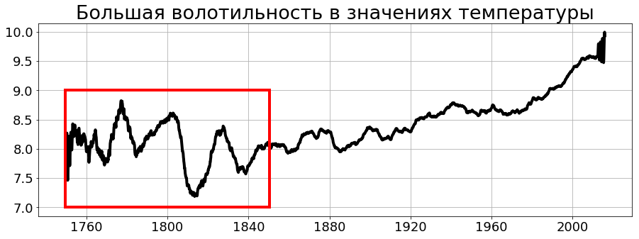

```python
plt.figure(figsize=(15, 5))
plot_land_avg_temperature(ax, temperature, 7, is_reg_visible=False)
plt.title('Большая волотильность в значениях температуры', fontsize=18 * 1.5)
plt.plot([datetime(year=1850, month=7, day=1)] * 2, [7, 9], 'r-', linewidth=4)
plt.plot([datetime(year=1749, month=7, day=1)] * 2, [7, 9], 'r-', linewidth=4)
x_box = [datetime(year=1749, month=7, day=1), datetime(year=1850, month=7, day=1)]
plt.plot(x_box, [7, 7], 'r-', linewidth=4)
plt.plot(x_box, [9, 9], 'r-', linewidth=4);
```

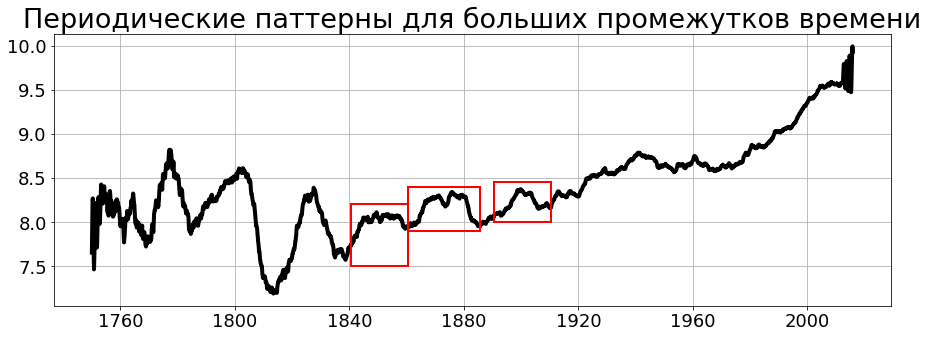

```python
plt.figure(figsize=(15, 5))
plot_land_avg_temperature(ax, temperature, 7, is_reg_visible=False)
plt.title('Периодические паттерны для больших промежутков времени', fontsize=18 * 1.5)

plt.plot([datetime(year=1840, month=7, day=1)] * 2, [7.5, 8.2], 'r-', linewidth=2)
plt.plot([datetime(year=1860, month=7, day=1)] * 2, [7.5, 8.2], 'r-', linewidth=2)
x_box = [datetime(year=1840, month=7, day=1), datetime(year=1860, month=7, day=1)]
plt.plot(x_box, [7.5, 7.5], 'r-', linewidth=2)
plt.plot(x_box, [8.2, 8.2], 'r-', linewidth=2)

plt.plot([datetime(year=1860, month=7, day=1)] * 2, [7.9, 8.4], 'r-', linewidth=2)
plt.plot([datetime(year=1885, month=7, day=1)] * 2, [7.9, 8.4], 'r-', linewidth=2)
x_box = [datetime(year=1860, month=7, day=1), datetime(year=1885, month=7, day=1)]
plt.plot(x_box, [7.9, 7.9], 'r-', linewidth=2)
plt.plot(x_box, [8.4, 8.4], 'r-', linewidth=2)

plt.plot([datetime(year=1890, month=7, day=1)] * 2, [8., 8.45], 'r-', linewidth=2)
plt.plot([datetime(year=1910, month=7, day=1)] * 2, [8., 8.45], 'r-', linewidth=2)
x_box = [datetime(year=1890, month=7, day=1), datetime(year=1910, month=7, day=1)]
plt.plot(x_box, [8., 8.], 'r-', linewidth=2)
plt.plot(x_box, [8.45, 8.45], 'r-', linewidth=2);
```

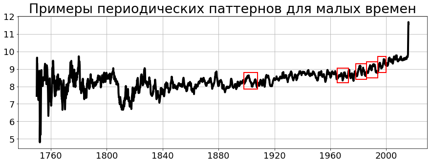

```python
def bbox_plot(year_s, year_f, bottom, top):
    plt.plot([datetime(year=year_s, month=1, day=1)] * 2, [bottom, top], 'r-', linewidth=2)
    plt.plot([datetime(year=year_f, month=1, day=1)] * 2, [bottom, top], 'r-', linewidth=2)
    x_box = [datetime(year=year_s, month=1, day=1), datetime(year=year_f, month=1, day=1)]
    plt.plot(x_box, [bottom] * 2, 'r-', linewidth=2)
    plt.plot(x_box, [top] * 2, 'r-', linewidth=2)

plt.figure(figsize=(15, 5))
plot_land_avg_temperature(ax, temperature, 1, is_reg_visible=False)
plt.title('Примеры периодических паттернов для малых времен', fontsize=18 * 1.5)

bbox_plot(1978, 1986, 8.4, 9.3)
bbox_plot(1986, 1994, 8.5, 9.4)
bbox_plot(1994, 2000, 8.8, 9.7)
bbox_plot(1965, 1973, 8.2, 9.05)
bbox_plot(1898, 1908, 7.85, 8.8)
```

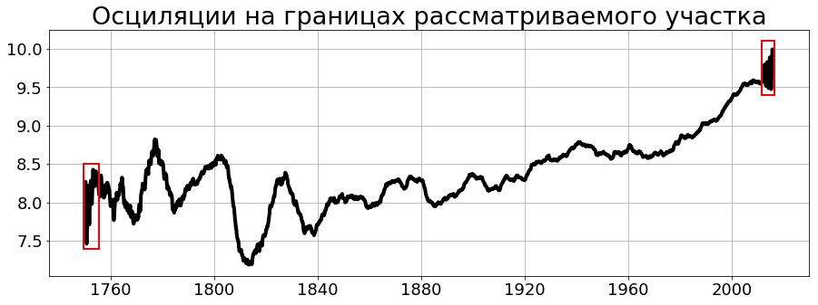

```python
plt.figure(figsize=(15, 5))
plot_land_avg_temperature(ax, temperature, 7, is_reg_visible=False)
plt.title('Осциляции на границах рассматриваемого участка', fontsize=18 * 1.5)

plt.plot([datetime(year=1755, month=7, day=1)] * 2, [7.4, 8.5], 'r-', linewidth=2)
plt.plot([datetime(year=1749, month=7, day=1)] * 2, [7.4, 8.5], 'r-', linewidth=2)
x_box = [datetime(year=1749, month=7, day=1), datetime(year=1755, month=7, day=1)]
plt.plot(x_box, [7.4, 7.4], 'r-', linewidth=2)
plt.plot(x_box, [8.5, 8.5], 'r-', linewidth=2)

plt.plot([datetime(year=2011, month=7, day=1)] * 2, [9.4, 10.1], 'r-', linewidth=2)
plt.plot([datetime(year=2016, month=7, day=1)] * 2, [9.4, 10.1], 'r-', linewidth=2)
x_box = [datetime(year=2011, month=7, day=1), datetime(year=2016, month=7, day=1)]
plt.plot(x_box, [9.4] * 2, 'r-', linewidth=2)
plt.plot(x_box, [10.1] * 2, 'r-', linewidth=2);
```

# Погрешности измерений

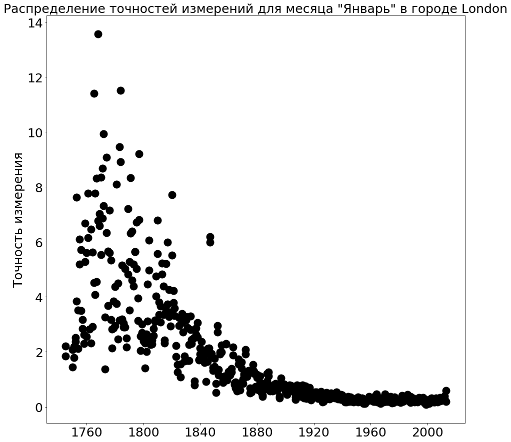

```python
month_name = ['Январь', 'Февраль', 'Март', 'Апрель', 'Май', 'Июнь', 'Июль', 'Август', 'Сентябрь', 'Октябрь', 'Ноябрь', 'Декарбрь']

month_num = 1
city_name = 'London' # cities_names[250]
filtered = city[city['City'] == city_name]
filtered = filtered[filtered['dt'].apply(lambda row: row.month) == month_num].dropna()
fontsize = 25
plt.figure(figsize=(15, 15))
plt.plot(filtered['dt'][filtered['City'] == city_name], filtered['AverageTemperatureUncertainty'][filtered['City'] == city_name], 'ko', markersize=15);
plt.title('Распределение точностей измерений для месяца "%s" в городе %s' % (month_name[month_num - 1], city_name), fontsize=fontsize)
plt.ylabel('Точность измерения', fontsize=fontsize)
plt.xticks(fontsize=fontsize)
plt.yticks(fontsize=fontsize);
```

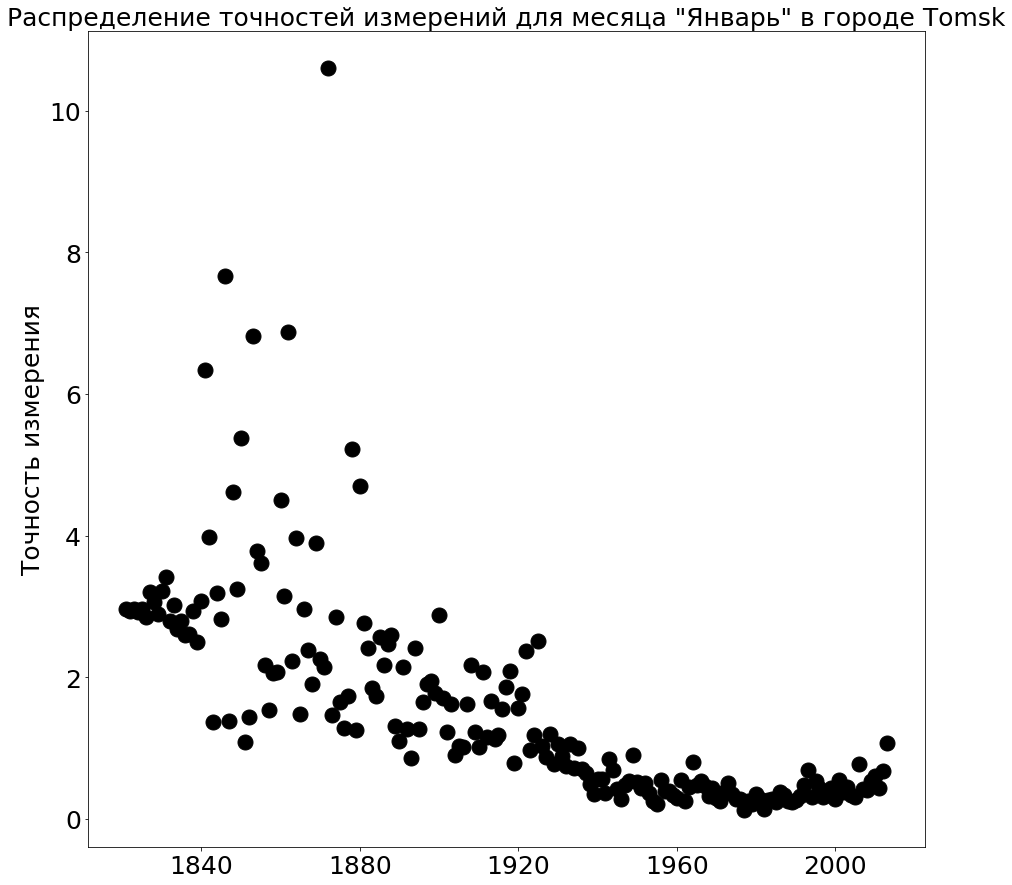

```python
month_name = ['Январь', 'Февраль', 'Март', 'Апрель', 'Май', 'Июнь', 'Июль', 'Август', 'Сентябрь', 'Октябрь', 'Ноябрь', 'Декарбрь']

month_num = 1
city_name = 'Tomsk' # cities_names[250]
filtered = city[city['City'] == city_name]
filtered = filtered[filtered['dt'].apply(lambda row: row.month) == month_num].dropna()
fontsize = 25
plt.figure(figsize=(15, 15))
plt.plot(filtered['dt'][filtered['City'] == city_name], filtered['AverageTemperatureUncertainty'][filtered['City'] == city_name], 'ko', markersize=15);
plt.title('Распределение точностей измерений для месяца "%s" в городе %s' % (month_name[month_num - 1], city_name), fontsize=fontsize)
plt.ylabel('Точность измерения', fontsize=fontsize)
plt.xticks(fontsize=fontsize)
plt.yticks(fontsize=fontsize);
```

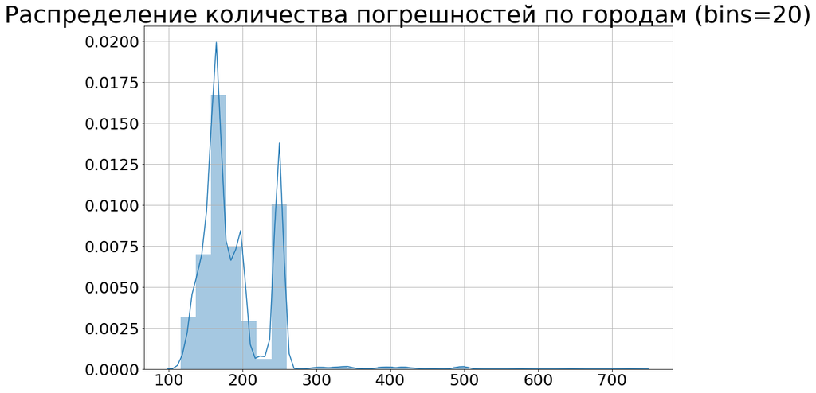

```python
counts = np.array([[item for item in stat['count'].values()] for stat in stats]).flatten()
plt.figure(figsize=(15, 10))
sns.distplot(counts, bins=30)
plt.title('Распределение количества погрешностей по городам (bins=20)', fontsize=fontsize*1.5)
plt.xticks(fontsize=fontsize)
plt.yticks(fontsize=fontsize)
plt.grid(True)
ax.spines['right'].set_visible(False)
ax.spines['top'].set_visible(False)
```

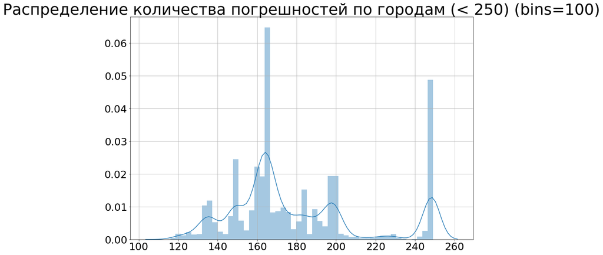

```python
counts = np.array([[item for item in stat['count'].values()] for stat in stats]).flatten()
plt.figure(figsize=(15, 10))
sns.distplot(counts[counts < 250], bins=50)
plt.title('Распределение количества погрешностей по городам (< 250) (bins=100)', fontsize=fontsize*1.5)
plt.xticks(fontsize=fontsize)
plt.yticks(fontsize=fontsize)
plt.grid(True)
ax.spines['right'].set_visible(False)
ax.spines['top'].set_visible(False)
```

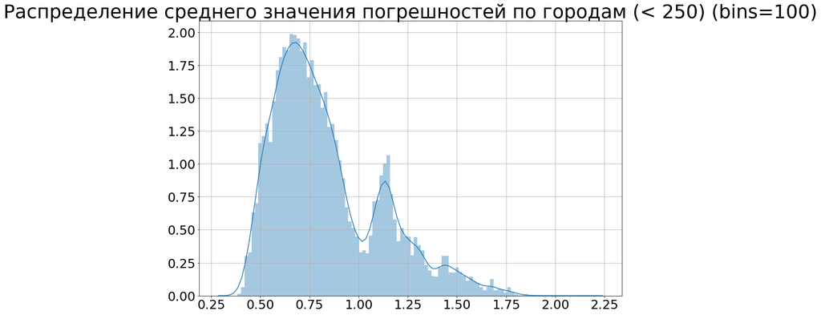

```python
plt.figure(figsize=(15, 10))
counts = np.array([[item for item in stat['mean'].values()] for stat in stats]).flatten()
sns.distplot(counts[counts < 250], bins=100)
plt.title('Распределение среднего значения погрешностей по городам (< 250) (bins=100)', fontsize=fontsize*1.5)
plt.xticks(fontsize=fontsize)
plt.yticks(fontsize=fontsize)
plt.grid(True)
ax.spines['right'].set_visible(False)
ax.spines['top'].set_visible(False)
```

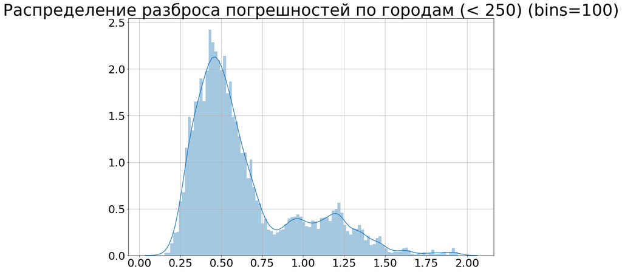

```python
plt.figure(figsize=(15, 10))
counts = np.array([[item for item in stat['sigma'].values()] for stat in stats]).flatten()
sns.distplot(counts[counts < 250], bins=100)
plt.title('Распределение разброса погрешностей по городам (< 250) (bins=100)', fontsize=fontsize*1.5)
plt.xticks(fontsize=fontsize)
plt.yticks(fontsize=fontsize)
plt.grid(True)
ax.spines['right'].set_visible(False)
ax.spines['top'].set_visible(False)
```

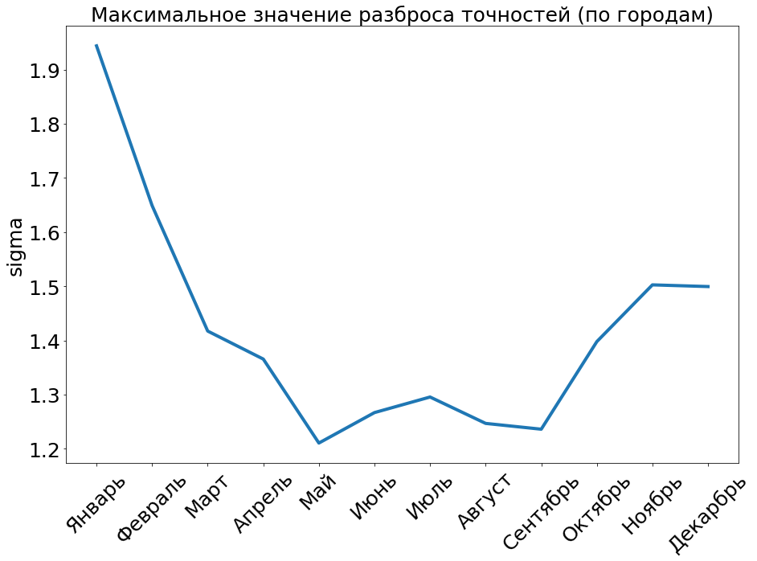

```python
max_sigma = []
for month_number in range(1, 13):
    max_sigma.append(max([value[1] for value in sorted(list(stats[month_number-1]['sigma'].items()), key=lambda x: x[0])]))

month_name = ['Январь', 'Февраль', 'Март', 'Апрель', 'Май', 'Июнь', 'Июль', 'Август', 'Сентябрь', 'Октябрь', 'Ноябрь', 'Декарбрь']
plt.figure(figsize=(15, 10))
plt.plot(month_name, max_sigma, linewidth=4)
plt.xticks(rotation=45)
plt.ylabel('sigma', fontsize=fontsize)
plt.title('Максимальное значение разброса точностей (по городам)', fontsize=fontsize)
plt.xticks(fontsize=fontsize)
plt.yticks(fontsize=fontsize);
```

# Так есть ли глобальное потепление?

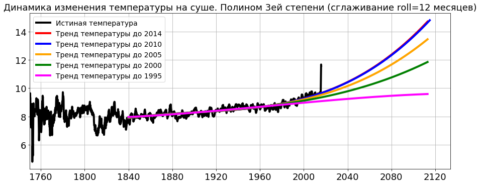

```python
plt.figure(figsize=(15, 4))
plt.subplots_adjust(top=1.2)

start_year = 1840
roll_year = 1
x = temperature['dt']
mask_year = np.where((x > datetime(year=start_year, day=1, month=1)) & (x < datetime(year=2014, day=1, month=1)))
plot_land_avg_temperature(ax, temperature, roll_year, mask_year, is_reg_visible=True, delta_reg_year=100)
mask_year = np.where((x > datetime(year=start_year, day=1, month=1)) & (x < datetime(year=2010, day=1, month=1)))
plot_land_avg_temperature(ax, temperature, roll_year, mask_year, is_general_visible=False, is_reg_visible=True, delta_reg_year=106, reg_color='blue')
mask_year = np.where((x > datetime(year=start_year, day=1, month=1)) & (x < datetime(year=2005, day=1, month=1)))
plot_land_avg_temperature(ax, temperature, roll_year, mask_year, is_general_visible=False, is_reg_visible=True, delta_reg_year=109, reg_color='orange')
mask_year = np.where((x > datetime(year=start_year, day=1, month=1)) & (x < datetime(year=2000, day=1, month=1)))
plot_land_avg_temperature(ax, temperature, roll_year, mask_year, is_general_visible=False, is_reg_visible=True, delta_reg_year=114, reg_color='green')
mask_year = np.where((x > datetime(year=start_year, day=1, month=1)) & (x < datetime(year=1995, day=1, month=1)))
plot_land_avg_temperature(ax, temperature, roll_year, mask_year, is_general_visible=False, is_reg_visible=True, delta_reg_year=119, reg_color='magenta')


plt.legend(['Истиная температура', 'Тренд температуры до 2014', 'Тренд температуры до 2010', 'Тренд температуры до 2005', 'Тренд температуры до 2000', 'Тренд температуры до 1995'], fontsize=14)
plt.title('Динамика изменения температуры на суше. Полином 3ей степени (сглаживание roll=12 месяцев)', fontsize=18);
```

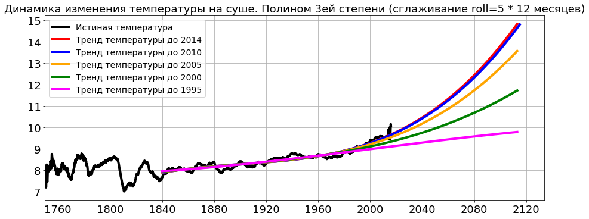

```python
plt.figure(figsize=(15, 4))
plt.subplots_adjust(top=1.2)

start_year = 1840
roll_year = 5
x = temperature['dt']
mask_year = np.where((x > datetime(year=start_year, day=1, month=1)) & (x < datetime(year=2014, day=1, month=1)))
plot_land_avg_temperature(ax, temperature, roll_year, mask_year, is_reg_visible=True, delta_reg_year=100)
mask_year = np.where((x > datetime(year=start_year, day=1, month=1)) & (x < datetime(year=2010, day=1, month=1)))
plot_land_avg_temperature(ax, temperature, roll_year, mask_year, is_general_visible=False, is_reg_visible=True, delta_reg_year=106, reg_color='blue')
mask_year = np.where((x > datetime(year=start_year, day=1, month=1)) & (x < datetime(year=2005, day=1, month=1)))
plot_land_avg_temperature(ax, temperature, roll_year, mask_year, is_general_visible=False, is_reg_visible=True, delta_reg_year=109, reg_color='orange')
mask_year = np.where((x > datetime(year=start_year, day=1, month=1)) & (x < datetime(year=2000, day=1, month=1)))
plot_land_avg_temperature(ax, temperature, roll_year, mask_year, is_general_visible=False, is_reg_visible=True, delta_reg_year=114, reg_color='green')
mask_year = np.where((x > datetime(year=start_year, day=1, month=1)) & (x < datetime(year=1995, day=1, month=1)))
plot_land_avg_temperature(ax, temperature, roll_year, mask_year, is_general_visible=False, is_reg_visible=True, delta_reg_year=119, reg_color='magenta')


plt.legend(['Истиная температура', 'Тренд температуры до 2014', 'Тренд температуры до 2010', 'Тренд температуры до 2005', 'Тренд температуры до 2000', 'Тренд температуры до 1995'], fontsize=14)
plt.title('Динамика изменения температуры на суше. Полином 3ей степени (сглаживание roll=5 * 12 месяцев)', fontsize=18);
```

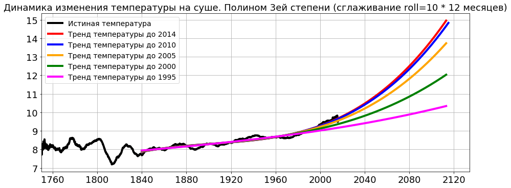

```python
plt.figure(figsize=(15, 4))
plt.subplots_adjust(top=1.2)

start_year = 1840
roll_year = 10
x = temperature['dt']
mask_year = np.where((x > datetime(year=start_year, day=1, month=1)) & (x < datetime(year=2014, day=1, month=1)))
plot_land_avg_temperature(ax, temperature, roll_year, mask_year, is_reg_visible=True, delta_reg_year=100)
mask_year = np.where((x > datetime(year=start_year, day=1, month=1)) & (x < datetime(year=2010, day=1, month=1)))
plot_land_avg_temperature(ax, temperature, roll_year, mask_year, is_general_visible=False, is_reg_visible=True, delta_reg_year=106, reg_color='blue')
mask_year = np.where((x > datetime(year=start_year, day=1, month=1)) & (x < datetime(year=2005, day=1, month=1)))
plot_land_avg_temperature(ax, temperature, roll_year, mask_year, is_general_visible=False, is_reg_visible=True, delta_reg_year=109, reg_color='orange')
mask_year = np.where((x > datetime(year=start_year, day=1, month=1)) & (x < datetime(year=2000, day=1, month=1)))
plot_land_avg_temperature(ax, temperature, roll_year, mask_year, is_general_visible=False, is_reg_visible=True, delta_reg_year=114, reg_color='green')
mask_year = np.where((x > datetime(year=start_year, day=1, month=1)) & (x < datetime(year=1995, day=1, month=1)))
plot_land_avg_temperature(ax, temperature, roll_year, mask_year, is_general_visible=False, is_reg_visible=True, delta_reg_year=119, reg_color='magenta')


plt.legend(['Истиная температура', 'Тренд температуры до 2014', 'Тренд температуры до 2010', 'Тренд температуры до 2005', 'Тренд температуры до 2000', 'Тренд температуры до 1995'], fontsize=14)
plt.title('Динамика изменения температуры на суше. Полином 3ей степени (сглаживание roll=10 * 12 месяцев)', fontsize=18);
```

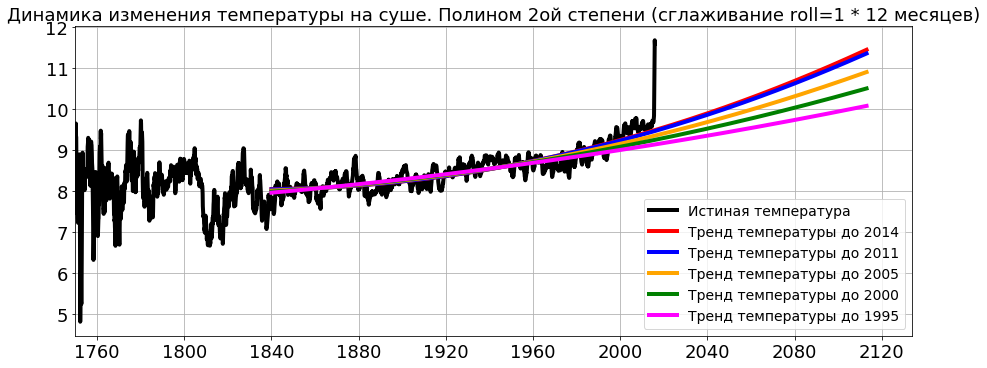

```python
plt.figure(figsize=(15, 4))
plt.subplots_adjust(top=1.2)

start_year = 1840
roll_year = 1
x = temperature['dt']
mask_year = np.where((x > datetime(year=start_year, day=1, month=1)) & (x < datetime(year=2014, day=1, month=1)))
plot_land_avg_temperature(ax, temperature, roll_year, mask_year, is_reg_visible=True, delta_reg_year=100, deg=2)
mask_year = np.where((x > datetime(year=start_year, day=1, month=1)) & (x < datetime(year=2011, day=1, month=1)))
plot_land_avg_temperature(ax, temperature, roll_year, mask_year, is_general_visible=False, is_reg_visible=True, delta_reg_year=103, reg_color='blue', deg=2)
mask_year = np.where((x > datetime(year=start_year, day=1, month=1)) & (x < datetime(year=2005, day=1, month=1)))
plot_land_avg_temperature(ax, temperature, roll_year, mask_year, is_general_visible=False, is_reg_visible=True, delta_reg_year=109, reg_color='orange', deg=2)
mask_year = np.where((x > datetime(year=start_year, day=1, month=1)) & (x < datetime(year=2000, day=1, month=1)))
plot_land_avg_temperature(ax, temperature, roll_year, mask_year, is_general_visible=False, is_reg_visible=True, delta_reg_year=114, reg_color='green', deg=2)
mask_year = np.where((x > datetime(year=start_year, day=1, month=1)) & (x < datetime(year=1995, day=1, month=1)))
plot_land_avg_temperature(ax, temperature, roll_year, mask_year, is_general_visible=False, is_reg_visible=True, delta_reg_year=119, reg_color='magenta', deg=2)


plt.legend(['Истиная температура', 'Тренд температуры до 2014', 'Тренд температуры до 2011', 'Тренд температуры до 2005', 'Тренд температуры до 2000', 'Тренд температуры до 1995'], fontsize=14)
plt.title('Динамика изменения температуры на суше. Полином 2ой степени (сглаживание roll=1 * 12 месяцев)', fontsize=18);
```

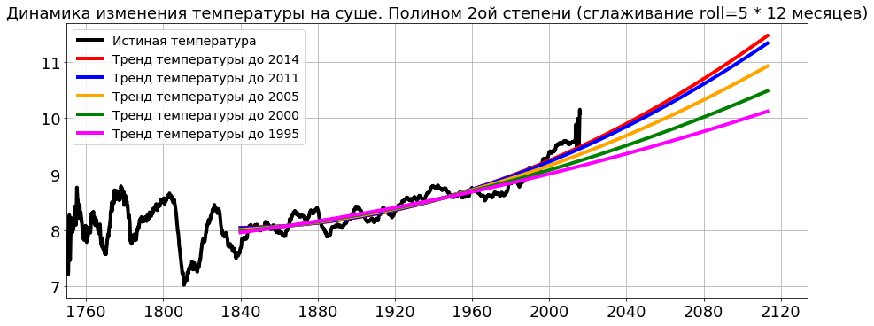

```python
plt.figure(figsize=(15, 4))
plt.subplots_adjust(top=1.2)

start_year = 1840
roll_year = 5
x = temperature['dt']
mask_year = np.where((x > datetime(year=start_year, day=1, month=1)) & (x < datetime(year=2014, day=1, month=1)))
plot_land_avg_temperature(ax, temperature, roll_year, mask_year, is_reg_visible=True, delta_reg_year=100, deg=2)
mask_year = np.where((x > datetime(year=start_year, day=1, month=1)) & (x < datetime(year=2011, day=1, month=1)))
plot_land_avg_temperature(ax, temperature, roll_year, mask_year, is_general_visible=False, is_reg_visible=True, delta_reg_year=103, reg_color='blue', deg=2)
mask_year = np.where((x > datetime(year=start_year, day=1, month=1)) & (x < datetime(year=2005, day=1, month=1)))
plot_land_avg_temperature(ax, temperature, roll_year, mask_year, is_general_visible=False, is_reg_visible=True, delta_reg_year=109, reg_color='orange', deg=2)
mask_year = np.where((x > datetime(year=start_year, day=1, month=1)) & (x < datetime(year=2000, day=1, month=1)))
plot_land_avg_temperature(ax, temperature, roll_year, mask_year, is_general_visible=False, is_reg_visible=True, delta_reg_year=114, reg_color='green', deg=2)
mask_year = np.where((x > datetime(year=start_year, day=1, month=1)) & (x < datetime(year=1995, day=1, month=1)))
plot_land_avg_temperature(ax, temperature, roll_year, mask_year, is_general_visible=False, is_reg_visible=True, delta_reg_year=119, reg_color='magenta', deg=2)


plt.legend(['Истиная температура', 'Тренд температуры до 2014', 'Тренд температуры до 2011', 'Тренд температуры до 2005', 'Тренд температуры до 2000', 'Тренд температуры до 1995'], fontsize=14)
plt.title('Динамика изменения температуры на суше. Полином 2ой степени (сглаживание roll=5 * 12 месяцев)', fontsize=18);
```

[figure not shown]

```python
plt.figure(figsize=(15, 4))
plt.subplots_adjust(top=1.2)

start_year = 1840
roll_year = 10
x = temperature['dt']
mask_year = np.where((x > datetime(year=start_year, day=1, month=1)) & (x < datetime(year=2014, day=1, month=1)))
plot_land_avg_temperature(ax, temperature, roll_year, mask_year, is_reg_visible=True, delta_reg_year=100, deg=2)
mask_year = np.where((x > datetime(year=start_year, day=1, month=1)) & (x < datetime(year=2011, day=1, month=1)))
plot_land_avg_temperature(ax, temperature, roll_year, mask_year, is_general_visible=False, is_reg_visible=True, delta_reg_year=103, reg_color='blue', deg=2)
mask_year = np.where((x > datetime(year=start_year, day=1, month=1)) & (x < datetime(year=2005, day=1, month=1)))
plot_land_avg_temperature(ax, temperature, roll_year, mask_year, is_general_visible=False, is_reg_visible=True, delta_reg_year=109, reg_color='orange', deg=2)
mask_year = np.where((x > datetime(year=start_year, day=1, month=1)) & (x < datetime(year=2000, day=1, month=1)))
plot_land_avg_temperature(ax, temperature, roll_year, mask_year, is_general_visible=False, is_reg_visible=True, delta_reg_year=114, reg_color='green', deg=2)
mask_year = np.where((x > datetime(year=start_year, day=1, month=1)) & (x < datetime(year=1995, day=1, month=1)))
plot_land_avg_temperature(ax, temperature, roll_year, mask_year, is_general_visible=False, is_reg_visible=True, delta_reg_year=119, reg_color='magenta', deg=2)


plt.legend(['Истиная температура', 'Тренд температуры до 2014', 'Тренд температуры до 2011', 'Тренд температуры до 2005', 'Тренд температуры до 2000', 'Тренд температуры до 1995'], fontsize=14)
plt.title('Динамика изменения температуры на суше. Полином 2ой степени (сглаживание roll=10 * 12 месяцев)', fontsize=18);
```

# Параметризуем по коэффициентам регрессии

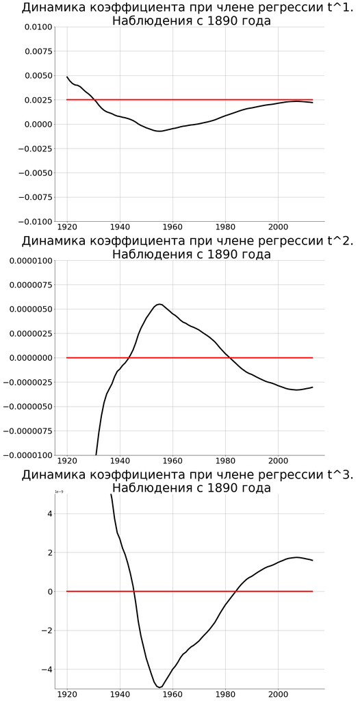

```python
coefs_ = []
deg = 3
roll_year = 10
a = 1890
b = 2014
history_interval = 30
x = temperature['dt']
for last_year in range(a + history_interval, b):
    mask_year = np.where((x > datetime(year=a, day=1, month=1)) & (x < datetime(year=last_year, day=1, month=1)))
    coefs_.append(plot_land_avg_temperature(ax, temperature, roll_year, mask_year, is_reg_visible=False, is_general_visible=False, deg=deg))
x_arg = [datetime(year=year, month=1, day=1) for year in range(a + history_interval, b)]

plt.figure(figsize=(15, 12))
plt.subplots_adjust(top=2.5)

ax = plt.subplot(311)
plt.plot(x_arg, np.array(coefs_)[:, 1], linewidth=4, color='k')
plt.plot(x_arg, [0.0025] * len(x_arg), linewidth=4, color='r')
plt.title('Динамика коэффициента при члене регрессии t^1. \n Наблюдения с %d года' % a, fontsize=fontsize*1.5)
plt.xticks(fontsize=fontsize)
plt.yticks(fontsize=fontsize)
plt.grid(True)
ax.spines['right'].set_visible(False)
ax.spines['top'].set_visible(False)
plt.ylim([-0.01, 0.01])

ax = plt.subplot(312)
plt.plot(x_arg, np.array(coefs_)[:, 2], linewidth=4, color='k')
plt.plot(x_arg, [0.0] * len(x_arg), linewidth=4, color='r')
plt.title('Динамика коэффициента при члене регрессии t^2. \n Наблюдения с %d года' % a, fontsize=fontsize*1.5)
plt.xticks(fontsize=fontsize)
plt.yticks(fontsize=fontsize)
plt.grid(True)
ax.spines['right'].set_visible(False)
ax.spines['top'].set_visible(False)
plt.ylim([-10e-6, 10e-6])

ax = plt.subplot(313)
plt.plot(x_arg, np.array(coefs_)[:, 3], linewidth=4, color='k')
plt.title('Динамика коэффициента при члене регрессии t^3. \n Наблюдения с %d года' % a, fontsize=fontsize*1.5)
plt.xticks(fontsize=fontsize)
plt.yticks(fontsize=fontsize)
plt.grid(True)
ax.spines['right'].set_visible(False)
ax.spines['top'].set_visible(False)
plt.plot(x_arg, [0.0] * len(x_arg), linewidth=4, color='r')
plt.ylim([-5e-9, 5e-9]);
```

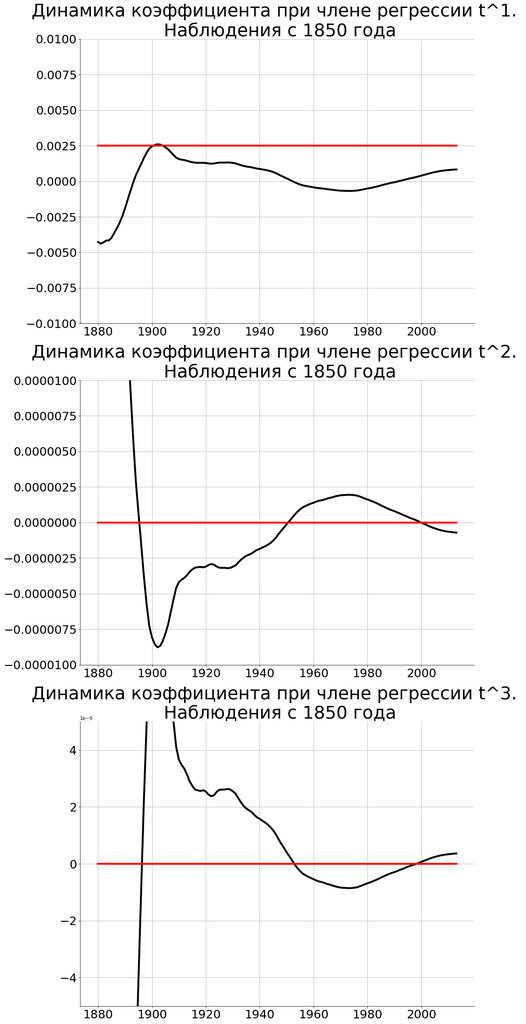

```python
coefs_ = []
deg = 3
roll_year = 10
a = 1850
b = 2014
history_interval = 30
x = temperature['dt']
for last_year in range(a + history_interval, b):
    mask_year = np.where((x > datetime(year=a, day=1, month=1)) & (x < datetime(year=last_year, day=1, month=1)))
    coefs_.append(plot_land_avg_temperature(ax, temperature, roll_year, mask_year, is_reg_visible=False, is_general_visible=False, deg=deg))
x_arg = [datetime(year=year, month=1, day=1) for year in range(a + history_interval, b)]

plt.figure(figsize=(15, 12))
plt.subplots_adjust(top=2.5)

ax = plt.subplot(311)
plt.plot(x_arg, np.array(coefs_)[:, 1], linewidth=4, color='k')
plt.plot(x_arg, [0.0025] * len(x_arg), linewidth=4, color='r')
plt.title('Динамика коэффициента при члене регрессии t^1. \n Наблюдения с %d года' % a, fontsize=fontsize*1.5)
plt.xticks(fontsize=fontsize)
plt.yticks(fontsize=fontsize)
plt.grid(True)
ax.spines['right'].set_visible(False)
ax.spines['top'].set_visible(False)
plt.ylim([-0.01, 0.01])

ax = plt.subplot(312)
plt.plot(x_arg, np.array(coefs_)[:, 2], linewidth=4, color='k')
plt.plot(x_arg, [0.0] * len(x_arg), linewidth=4, color='r')
plt.title('Динамика коэффициента при члене регрессии t^2. \n Наблюдения с %d года' % a, fontsize=fontsize*1.5)
plt.xticks(fontsize=fontsize)
plt.yticks(fontsize=fontsize)
plt.grid(True)
ax.spines['right'].set_visible(False)
ax.spines['top'].set_visible(False)
plt.ylim([-10e-6, 10e-6])

ax = plt.subplot(313)
plt.plot(x_arg, np.array(coefs_)[:, 3], linewidth=4, color='k')
plt.title('Динамика коэффициента при члене регрессии t^3. \n Наблюдения с %d года' % a, fontsize=fontsize*1.5)
plt.xticks(fontsize=fontsize)
plt.yticks(fontsize=fontsize)
plt.grid(True)
ax.spines['right'].set_visible(False)
ax.spines['top'].set_visible(False)
plt.plot(x_arg, [0.0] * len(x_arg), linewidth=4, color='r')
plt.ylim([-5e-9, 5e-9]);
```

# Изучим вопрос засухи и холодов

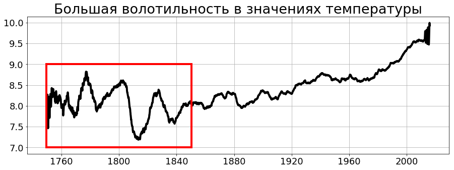

```python
plt.figure(figsize=(15, 5))
plot_land_avg_temperature(ax, temperature, 7, is_reg_visible=False)
plt.title('Большая волотильность в значениях температуры', fontsize=18 * 1.5)
plt.plot([datetime(year=1850, month=7, day=1)] * 2, [7, 9], 'r-', linewidth=4)
plt.plot([datetime(year=1749, month=7, day=1)] * 2, [7, 9], 'r-', linewidth=4)
x_box = [datetime(year=1749, month=7, day=1), datetime(year=1850, month=7, day=1)]
plt.plot(x_box, [7, 7], 'r-', linewidth=4)
plt.plot(x_box, [9, 9], 'r-', linewidth=4);
```

Во некоторых источниках упоминается про пожары, холода и другие катаклизмы в отмеченные периоды. Посмотрим, что же на самом деле

```python
groupped_cities_hot, groupped_cities_cold, groupped_cities_diff = failure_filter_period(1809, 1814, 1800, 1804, winter_mask)

plotly_map_temperature(groupped_cities_hot, 'Средние температуры для зим 1800--1804')
plotly_map_temperature(groupped_cities_cold, 'Средние температуры для зим 1809--1814')
plotly_map_temperature(groupped_cities_diff, 'Разница между средними температурами для зим 1809--1814 и 1800--1804')
```

[interactive chart not shown]

```python
groupped_cities_hot, groupped_cities_cold, groupped_cities_diff = filter_period(1809, 1814, 1800, 1804, summer_mask)

plotly_map_temperature(groupped_cities_hot, 'Средние температуры для летних периодов 1800--1804')
plotly_map_temperature(groupped_cities_cold, 'Средние температуры для летних периодов 1809--1814')
plotly_map_temperature(groupped_cities_diff, 'Разница между средними температурами для летних периодов 1809--1814 и 1800--1804')
```

[interactive chart not shown]

А теперь посмотрим, что происходило за весь период наблюдения для различных уровней сглаживания

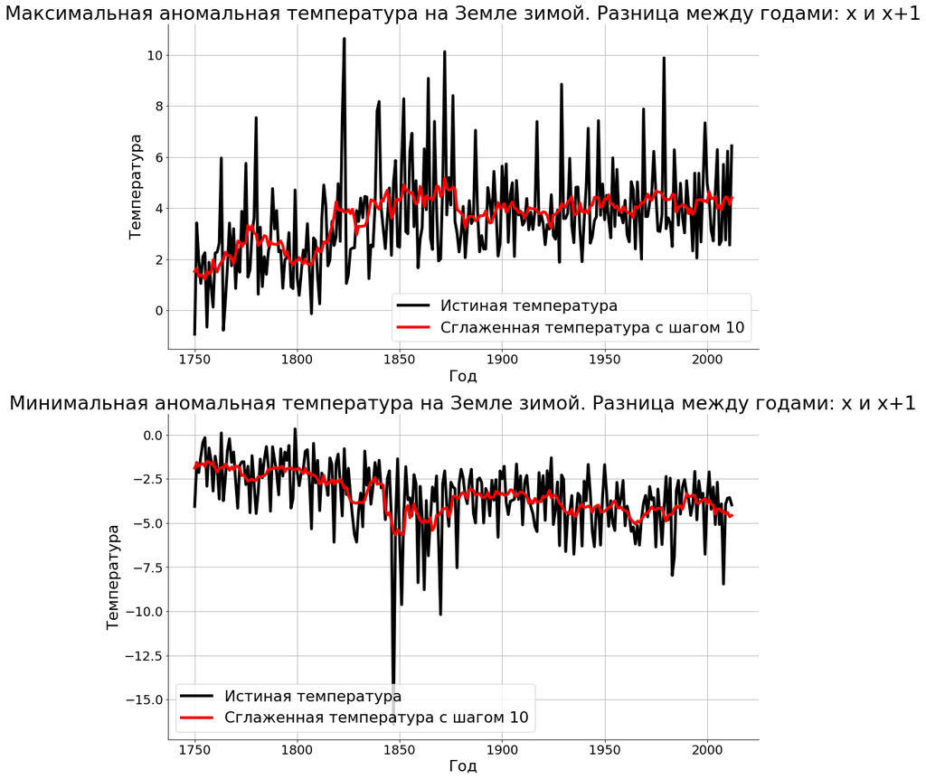

```python
calc_and_plot_extreme_temperature(winter_mask, 'зимой', 1750, 2013, 1)
```

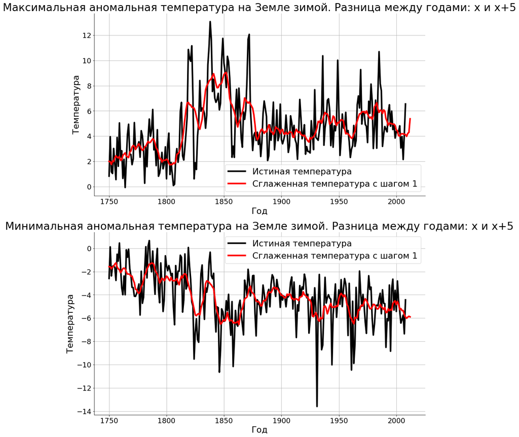

```python
calc_and_plot_extreme_temperature(winter_mask, 'зимой', 1750, 2013, 5, 3)
```

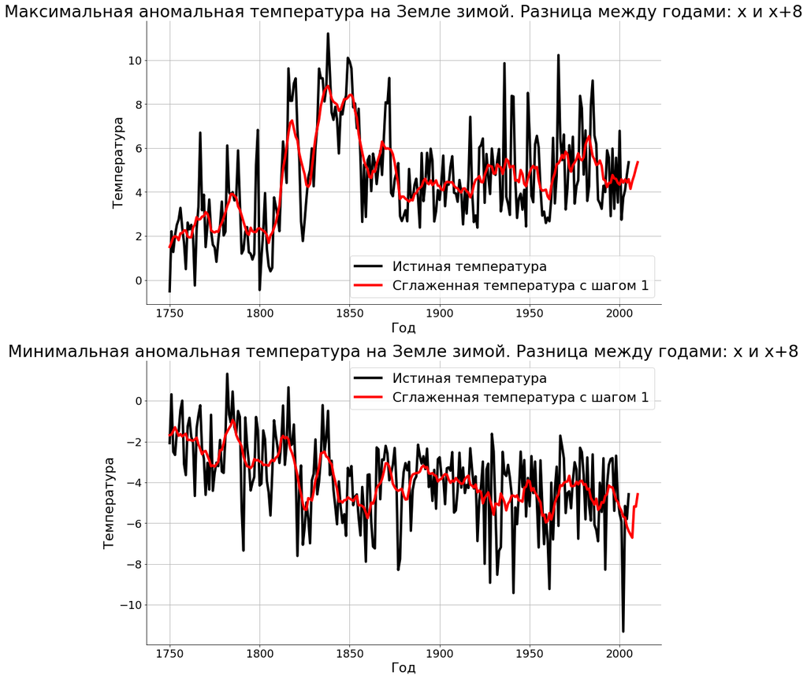

```python
calc_and_plot_extreme_temperature(winter_mask, 'зимой', 1750, 2013, 8, 5)
```